# Superstore dataset

Sargenti & Vallejo

2022-06-28

## 0.1 Objetivo

El presente documento tiene como objetivo el establecimiento de precios y cantidades para la maximización de los ingresos totales del SuperStore. Esto se podrá lograr a través del cumplimiento de los siguientes sub-objetivos:

1. Desarrollo de una metodologia del precio maximizador del ingreso total.
2. Determinar si el segmento del cliente es independiente al tipo de producto.
3. Metodologia de un sistema de promociones.

## 0.2 Desarrollo del Objetivo

Para el cumplimiento del objetivo propuesto se utilizará el algoritmo de regresión lineal. A partir del algoritmo de regresión, se obtendrá los coeficientes para la formación de la ecuación general de la demanda (Qd=B0 + B1*P), el porcentaje de variabilidad explicado por el modelo y el p-value. Este último validará el modelo una vez que sea menor a 0,05 con un nivel de confianza del 95%.

Ya validado el modelo, se obtiene la función de demanda, lo que permitirá calcular el ingreso total y así el precio maximizador del ingreso total. A su vez este procedimiento se realizará nuevamente, segmentando por categoría de producto, con el fin de evaluar el diferencias entre los precios maximizadores.

## 0.3 Descripción de las Variables a utilizar

La base SuperStore cuenta con 21 variables y 9994 registros.

```
##        Row ID      Order ID    Order Date     Ship Date     Ship Mode
##      "double"   "character"   "character"   "character"   "character"
##   Customer ID Customer Name       Segment       Country          City
##   "character"   "character"   "character"   "character"   "character"
##         State   Postal Code        Region    Product ID      Category
##   "character"      "double"   "character"   "character"   "character"
##  Sub-Category  Product Name         Sales      Quantity      Discount
##   "character"   "character"   "character"      "double"      "double"
##        Profit
##   "character"
```

Las variables que se utilizaron para hacer posible nuestro análisis relacionado al objetivo fueron:

1. “Segment”: Describe la categoría del cliente, la cuál puede variar entre Consumer, Corporate y Home Office. (Es de tipo Character)
2. “Category”: Describe la primera categoría por la cuál estan segmentados los productos. Entre ellas se encuentra Furniture, Technology y Office Supplies. (Es de tipo Character)
3. “Sales”:Describe el valor total de la compra realizada (Es de tipo Double)

4.”Quantity”:Describe la cantidad comprada del producto (Es de tipo Integer)

Ya se que durante el análisis se precisa una variables que contenga el precio por unidad, para poder así determinar la demanda, se creó esta variable de tipo Integer con el nombre de Price. Para esto, fue necesario hacer modificaciones en los tipo de dato de las variables Quatity y Sales. Para la unificación de los valores del data, se infirió sobre la variable Profit.

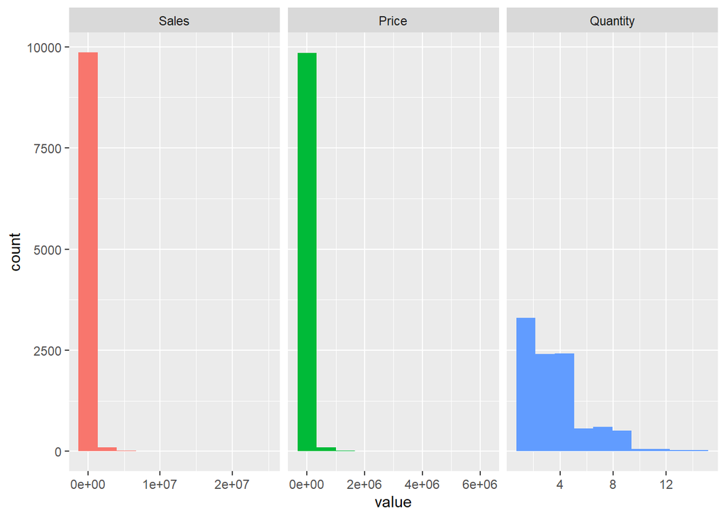

Las demas variables que no fueron nombradas, serán descartadas ya no que no fueron relevantes para el análisis del objetivo propuesto.

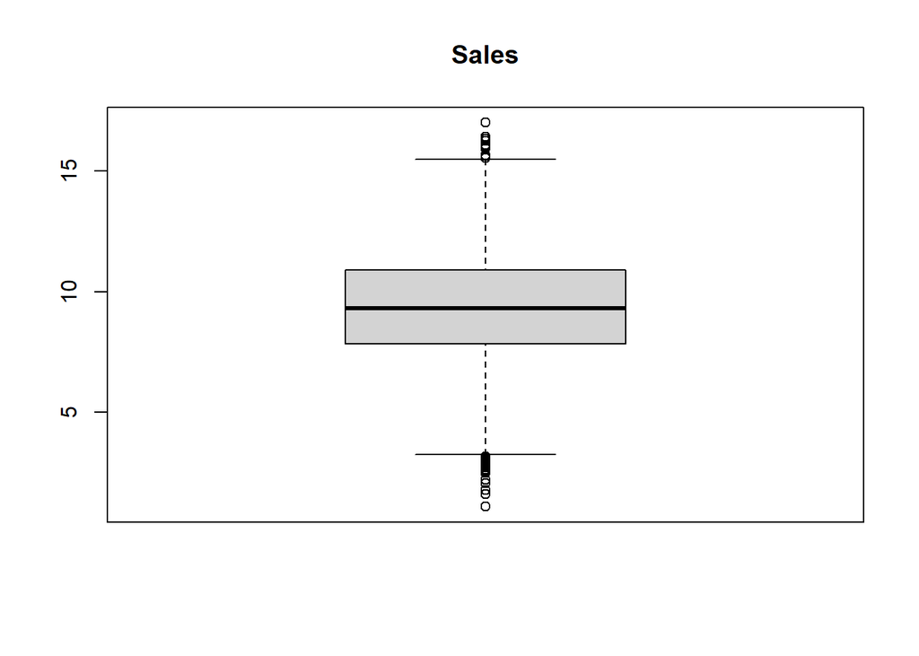

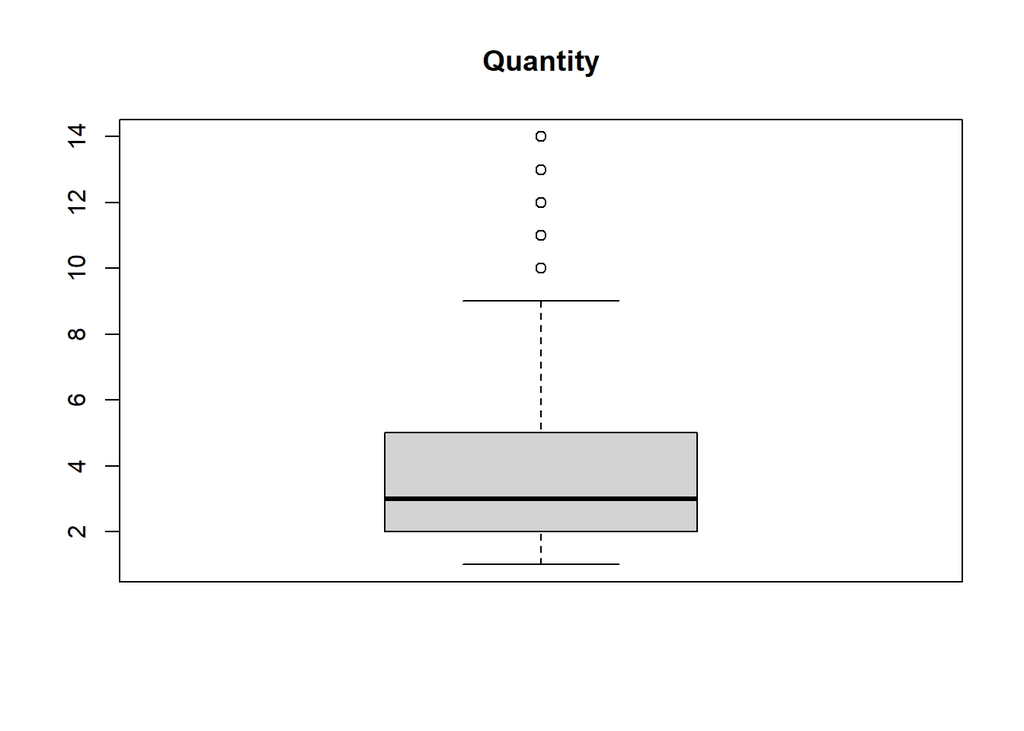

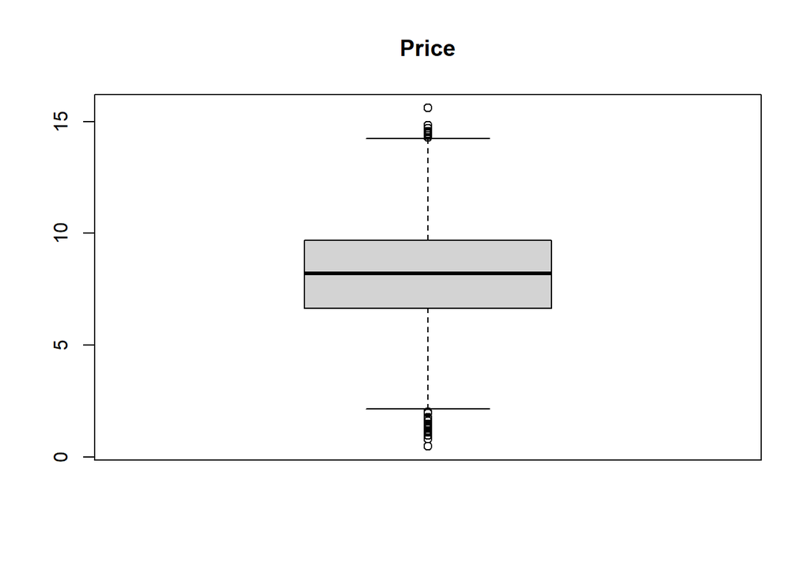

Si bien se encuentran outliers en las variables Sales y Price, estos no seran considerados como outliers, ya que la base presenta una división de productos con mucha variablidad entre sus precios. Es por eso que se decidió ver si en cada categoria de producto se encontraban outliers en estas variables.

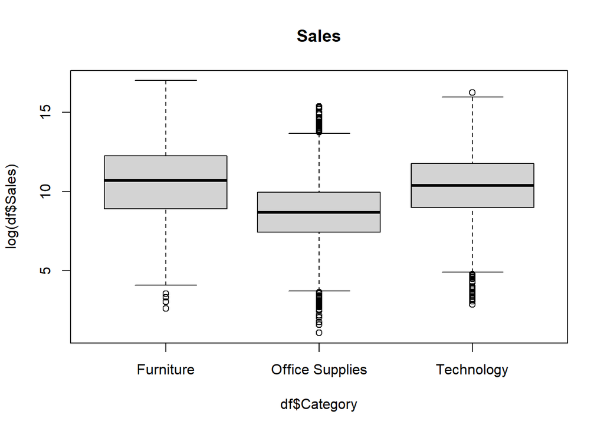

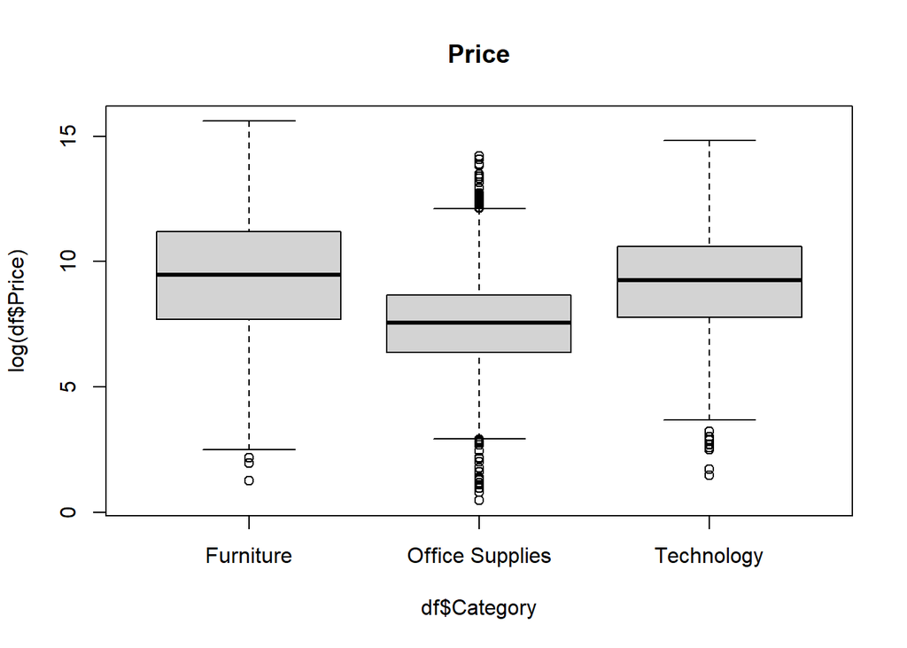

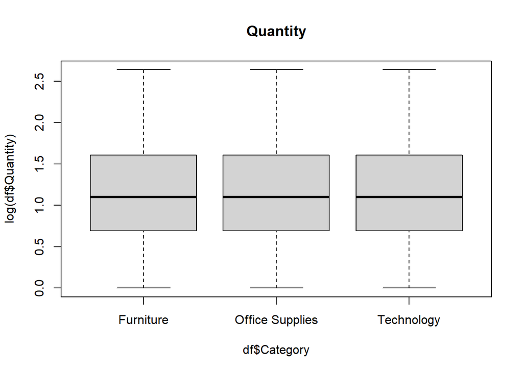

## 0.4 Lista de Variables

```
##      Sales             Quantity          Price           Category
##  Min.   :       3   Min.   : 1.000   Min.   :      2   Length:9994
##  1st Qu.:    2512   1st Qu.: 2.000   1st Qu.:    768   Class :character
##  Median :   11022   Median : 3.000   Median :   3622   Mode  :character
##  Mean   :  113155   Mean   : 3.789   Mean   :  31568
##  3rd Qu.:   53982   3rd Qu.: 5.000   3rd Qu.:  16096
##  Max.   :23962656   Max.   :14.000   Max.   :5990664
##  NA's   :6          NA's   :6        NA's   :6
##    Segment
##  Length:9994
##  Class :character
##  Mode  :character
##
##
##
##
```

A partir del resumen de cada variable, fue posible observar la gran magnitud entre los valores máximo y minímo de las variables númericas, en especial en Sales y Price. Esto es justificado debido a la gran variedad de productos, y en consecuencia a la difrencia entre las distintas sub categorías, y por lo tanto a la diferencia de precios entre sí.

## 0.5 Relación entre las Variables

```
##        Segment Furniture Office Supplies Technology
## 1:    Consumer      4166           11758       3593
## 2:   Corporate      2495            7018       2088
## 3: Home Office      1367            4130       1226
```

```
## [1] "Office Supplies" "Office Supplies" "Office Supplies"
```

A partir de la tabla armada, es posible notar que en cada Segmento de clientes, el tipo de producto más consumido es del tipo Office Supplies. Esto podria deberse a que los productos que se encuentran dentro de esta categoría, son elementos de consumo diario y no requiere una mayor inversion su compra.

Continuado con el análisis, se quiere conocer si la categoría comprada es independiente al segmento de cliente. Por lo tanto, se construye el siguiente test de hipotesis:

H0: Las variables son independientes

H1: Las variables son dependientes

```
##
##  Pearson's Chi-squared test
##
## data:  independecia_variables
## X-squared = 1.4612, df = 4, p-value = 0.8335
```

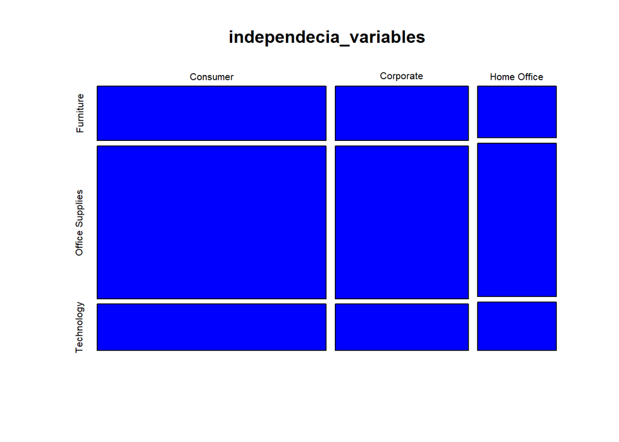

## 0.6 Técnicas de Análisis

Se quiere saber si existe algún tipo de relación entre la cantidad y el precio. Para ello, realizamos una regresión lineal de la demanda, al ser la regresión la herramienta la cuál nos permite encontrar una relación particular entre estas dos variables.

ECUACIÓN DE DEMANDA TOTAL

H0: El modelo no es válido

H1: El modelo si es válido

```
##
## Call:
## lm(formula = Quantity ~ Price, data = df)
##
## Residuals:
##     Min      1Q  Median      3Q     Max
## -2.8011 -1.7970 -0.7958  1.1991 10.2305
##
## Coefficients:
##               Estimate Std. Error t value Pr(>|t|)
## (Intercept)  3.801e+00  2.293e-02 165.778   <2e-16 ***
## Price       -3.957e-07  1.744e-07  -2.269   0.0233 *
## ---
## Signif. codes:  0 '***' 0.001 '**' 0.01 '*' 0.05 '.' 0.1 ' ' 1
##
## Residual standard error: 2.225 on 9986 degrees of freedom
##   (6 observations deleted due to missingness)
## Multiple R-squared:  0.0005154,  Adjusted R-squared:  0.0004153
## F-statistic: 5.149 on 1 and 9986 DF,  p-value: 0.02328
```

```
##   (Intercept)         Price
##  3.801138e+00 -3.956936e-07
```

Se obtiene un p -value igual a 0.02328, el cual es menor a 0.05,por lo tanto se rechaza H0 y se concluye que el modelo es válido con un nivel de significación del 95%.

H0: La variable Price no aporta al modelo propuesto

H1: La variable Precio aporta al modelo propuesto

α = 0,05

CR: Pr(>|t|) < 0,05

Pr(>|t|) =0.0233

Teniendo en cuenta que el Pr(>|t|) =0.0233 , es posible rechazar H0 y por lo tanto concluir que el precio sí aporta al modelo.

A partir de esto se fórmula la ecuacion de demanda total:

Qd = 3.801138e+00 -3.956936e-07 * P

Posteriormente se formula la ecuaciÓn de Ingreso total y el Ingreso Marginal:

IT = P*Q

IT = 3.801138e+00 P - 3.956936e-07 * P**2

IMg = 3.801138e+00 - 7.913872e-07 * P

El precio que maximiza el Ingreso Total es 4.803133^{6}, mientras que la cantidad que maximiza es 2.

Por lo tanto el Ingreso total Maximizado es igual a 9.6062661^{6}

A continuacion se mostrara el grafico de la ecuacion de demanda general:

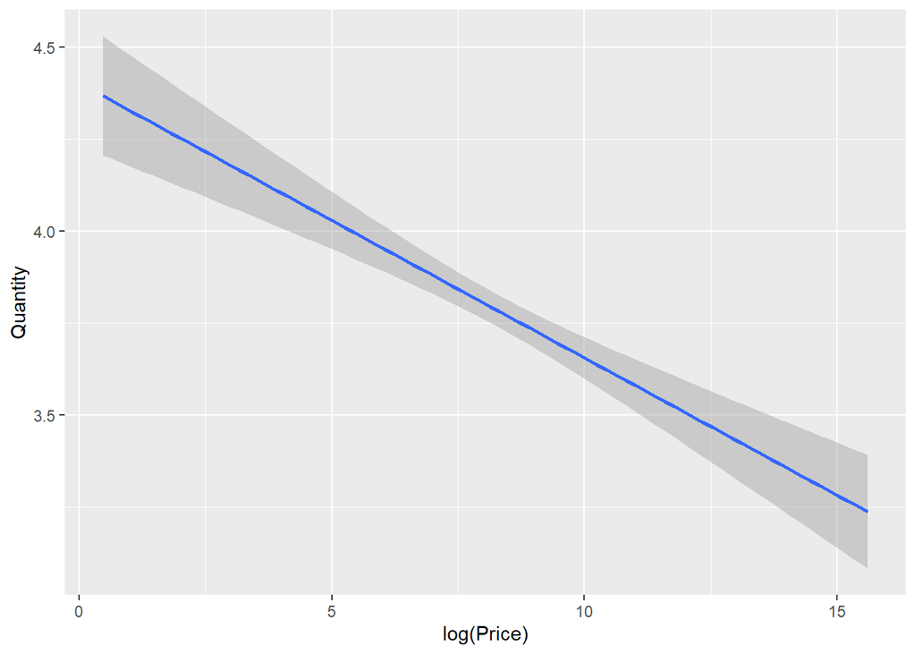

[figure not shown]

Debido a que los precios varian en relacion a cada cateoria de producto, se considero que es necesario evaluar la relacion no solo entre cantidad y precio, sino tambien considerando la categoria del producto. Es por eso que se volvio a utilizar el algoritmo de regresion lineal, pero esta vez agregando la categoria del producto como una variable mas en el analisis.

ECUACION DE DEMANDA PARA CADA CATEGORIA DE PRODUCTO

H0: El modelo no es válido

H1: El modelo si es válido

```
##
## Call:
## lm(formula = Quantity ~ 0 + Category + Price, data = df)
##
## Residuals:
##     Min      1Q  Median      3Q     Max
## -2.8129 -1.7977 -0.7908  1.1942 10.2602
##
## Coefficients:
##                           Estimate Std. Error t value Pr(>|t|)
## CategoryFurniture        3.813e+00  4.994e-02  76.357   <2e-16 ***
## CategoryOffice Supplies  3.806e+00  2.874e-02 132.427   <2e-16 ***
## CategoryTechnology       3.771e+00  5.259e-02  71.709   <2e-16 ***
## Price                   -3.922e-07  1.778e-07  -2.206   0.0274 *
## ---
## Signif. codes:  0 '***' 0.001 '**' 0.01 '*' 0.05 '.' 0.1 ' ' 1
##
## Residual standard error: 2.225 on 9984 degrees of freedom
##   (6 observations deleted due to missingness)
## Multiple R-squared:  0.7437, Adjusted R-squared:  0.7436
## F-statistic:  7243 on 4 and 9984 DF,  p-value: < 2.2e-16
```

Se obtiene un p -value igual a 2.2e-16, el cual es menor a 0.05,por lo tanto se rechaza H0 y se concluye que el modelo es vÁlido con un nivel de significaciÓn del 95%.

Qué tanto explica el modelo?

Adjusted R-squared: 0.7436

A continuacion se realizará un analisis de la demanda por cada categoria de Producto:

CATEGORIA FURNITURE:

H0: La variable Precio (Categoría Furniture) no aporta al modelo propuesto

H1: La variable Precio (Categoría Furniture) aporta al modelo propuesto

α = 0,05

CR: Pr(>|t|) < 0,05

A partir de esto se fórmula la ecuación de demanda de la categoría Furniture:

QdF = 3.813e+00 -3.922377e-07 * P

Posteriormente se formula la ecuación de Ingreso total y el Ingreso Marginal para la categoría Furniture:

IT = P*Q

IT = 3.813e+00* P - 3.922377e-07 * P**2

IMg = 3.813e+00 - 7.844754e-07 * P

A continuación se obtiene el precio y la cantidad que máximiza el Ingreso Total para la categoría Furniture.

El precio que maximiza el Ingreso Total para la categoría Furniture es 4.8605731^{6} y la cantidad es 2.

Por lo tanto el Ingreso total Maximizado para la categoría Furniture es 9.7211461^{6}

CATEGORÍA OFFICE SUPPLIES

H0: La variable Precio (Categoría Office Supplies) no aporta al modelo propuesto

H1: La variable Precio (Categoría Office Supplies) aporta al modelo propuesto

α = 0,05

CR: Pr(>|t|) < 0,05

A partir de esto se formula la ecuación de demanda de la categoría Office Supplies:

QdS = 3.806e+00 -3.922e-07 * P

Posteriormente se formula la ecuación de Ingreso total y el Ingreso Marginal para la categoría Office Supplies:

ITS = P*Q

ITS = 3.806e+00* P - 3.922377e-07 * P**2

IMgS = 3.806e+00 - 7.844754e-07 * P

A continuación se obtiene el precio y la cantidad que maximiza el Ingreso Total para la categoría Office Supplies.

El precio que maximiza el Ingreso Total para la categoría Office Supplies es 4.8516499^{6} y la cantidad es 2.

Por lo tanto el Ingreso total Maximizado para la categoría Office Supplies es 9.7032998^{6}

CATEGORÍA TECHNOLOGY

H0: La variable Precio (Categoría Technology) no aporta al modelo propuesto

H1: La variable Precio (Categoría Technology) aporta al modelo propuesto

α = 0,05

CR: Pr(>|t|) < 0,05

A partir de esto se formula la ecuación de demanda de la categoria Technology:

QdT = 3.771167e+00 - -3.922377e-07 * P

Posteriormente se formula la ecuación de Ingreso total y el Ingreso Marginal para la categoría Technology:

ITT = P*Q

ITT = 3.771167e+00* P - 3.922377e-07 * P**2

IMgT = 3.771167e+00 - 7.844754e-07 * P

A continuación se obtiene el precio y la cantidad que maximiza el Ingreso Total para la categoría Technology

Si bien el precio maximizador de la demanda general no difiere de manera significativa a los precios maximizadores por categoría, es preferible utilizar el precio maximizador de cada categoría al ser estos mayores al total.

```
## [1] 4803133
```

```
## [1] 4860573
```

```
## [1] 4851650
```

```
## [1] 4807247
```

A continuación se mostrara el gráfico de demanda por cada categoría:

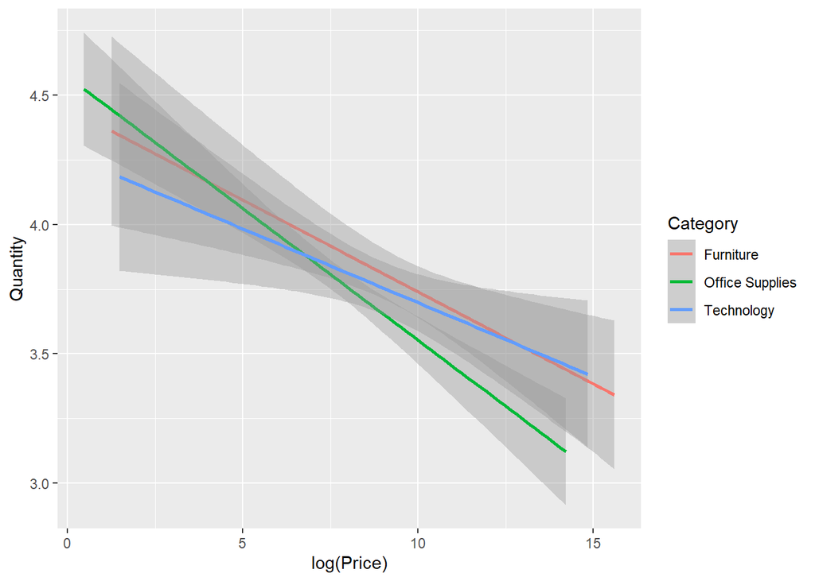

ELASTICIDAD

```
##
## Call:
## lm(formula = log(Quantity) ~ log(Price), data = df)
##
## Residuals:
##      Min       1Q   Median       3Q      Max
## -1.34037 -0.44836 -0.03685  0.40075  1.54705
##
## Coefficients:
##              Estimate Std. Error t value Pr(>|t|)
## (Intercept)  1.367144   0.022907  59.684   <2e-16 ***
## log(Price)  -0.024371   0.002694  -9.046   <2e-16 ***
## ---
## Signif. codes:  0 '***' 0.001 '**' 0.01 '*' 0.05 '.' 0.1 ' ' 1
##
## Residual standard error: 0.5837 on 9986 degrees of freedom
##   (6 observations deleted due to missingness)
## Multiple R-squared:  0.008128,   Adjusted R-squared:  0.008029
## F-statistic: 81.83 on 1 and 9986 DF,  p-value: < 2.2e-16
```

```
## (Intercept)  log(Price)
##  1.36714427 -0.02437098
```

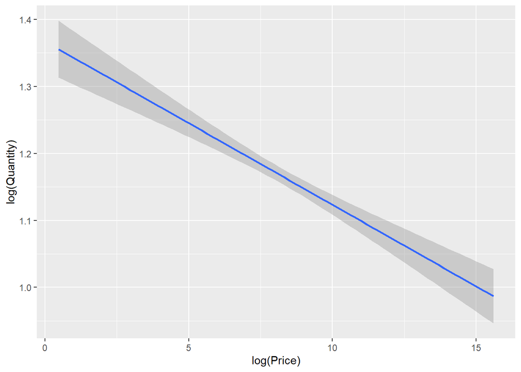

ELASTICIDAD POR CATEGORÍA DE PRODUCTO

```
##
## Call:
## lm(formula = log(Quantity) ~ 0 + Category + log(Price), data = df)
##
## Residuals:
##      Min       1Q   Median       3Q      Max
## -1.34852 -0.44677 -0.03275  0.40020  1.54543
##
## Coefficients:
##                          Estimate Std. Error t value Pr(>|t|)
## CategoryFurniture        1.422116   0.030025  47.364   <2e-16 ***
## CategoryOffice Supplies  1.378794   0.023241  59.327   <2e-16 ***
## CategoryTechnology       1.407594   0.029651  47.473   <2e-16 ***
## log(Price)              -0.027553   0.002908  -9.476   <2e-16 ***
## ---
## Signif. codes:  0 '***' 0.001 '**' 0.01 '*' 0.05 '.' 0.1 ' ' 1
##
## Residual standard error: 0.5835 on 9984 degrees of freedom
##   (6 observations deleted due to missingness)
## Multiple R-squared:  0.8004, Adjusted R-squared:  0.8003
## F-statistic: 1.001e+04 on 4 and 9984 DF,  p-value: < 2.2e-16
```

```
##       CategoryFurniture CategoryOffice Supplies      CategoryTechnology
##               1.4221163               1.3787937               1.4075944
##              log(Price)
##              -0.0275526
```

B1 es la elasticidad precio de la demanda, la cual representa el cambio porcentual en la cantidad demandada causado por un 1% de aumento en el precio.

B0 Furniture Intercept = 1.4221163

B0 Office Supplies Intercept = 1.3787937

B0 Technology Intercept = 1.4075944

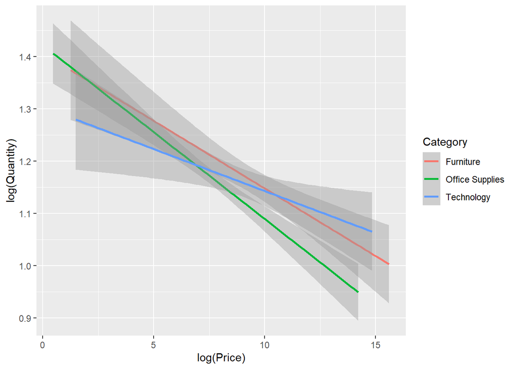

## 0.7 Conclusión

Se concluye que existe una correlación entre precio de producto y cantidad comprada lo cual fue posible establecer mediante regresión, permitiendo la maximización del ingreso total mediante el precio y cantidad maximizadores. A su vez también es posible afirmar que el precio maximizador puede variar por categoría de producto.